[figure not shown]

How to create applications  
using Shiny

ISGlobal

Barcelona, February 13-14th 2018

Part IV: Ways to improve the application

### Outline

**Part IV: Ways to improve the application**

- HTML and CSS
- Pop-ups and Modals
- Collapse panels
- Carrouselles
- Themes (app appearance)
- Sizeable.

HTML and CSS

### HTML and CSS

- Using **`HTML`** and **`div`** you can insert HTML code to change the form elements appearance, color, etc., insert links,…
- You can specify the element appearance in the header by using HTML function with `#age` linking to the element whose id is “age”.

```r
HTML("<style type='text/css'> #age{color: red} </style>")
```

- Or just wrapping the element by **`div`** function in the UI section.

```r
div(numericInput("age","Age",30), style="color:red")"
```

- You can also use **`HTML`** to change the color or insert a link to an input element label.

[figure not shown]

```r
numericInput("age", HTML("<p title='Enter your age'>Age</p>"),30))"
```

Note what happens when placing the mouse over “mu” or “sd” inputs label.

```r
ui <- fluidPage(
  headerPanel("HTML examples"),

  HTML("<style type='text/css'> #inputpanel{background-color: rgb(230,230,230);
       border: 2px solid grey; box-shadow: 2px 2px 1px #888888;} </style>"),
  HTML("<style type='text/css'> #outpanel { background-color: rgb(250,250,250);
       border: 2px solid grey; box-shadow: 2px 2px 1px #888888; overflow:scroll; height:500px} </style>"),
  HTML("<style type='text/css'> #inputpanel .wellPanel {background-color:rgb(215,215,215); </style>"),
  HTML("<style type='text/css'> #OK {color:white; background-color:rgb(10,101,212);
       border: solid 1px rgb(10,101,212)} </style>"),

  sidebarLayout(
    sidebarPanel(id="inputpanel",
      wellPanel(
        numericInput("mu", HTML("<p title='Enter the mean'>Mean</p>"), 0),
        numericInput("sd", HTML("<p title='Enter the standard deviation'>SD</p>"),3),
        actionButton("OK", "OK")
      )
    ),
    mainPanel(id="outpanel",
      plotOutput("results")
    )
  )
)

server <- function(input,output){
  output$results <- renderPlot({
    if (input$OK == 0) return(invisible(NULL))
    isolate({
      hist(rnorm(100, input$mu, input$sd), xlab="var", ylab = "frec", main = "")
    })
  }, 500, 500)
}

shinyApp(ui=ui,server=server)
```

Pop-ups and Modals

### Pop-ups

[figure not shown]

```r
library(shinyBS)

ui <- fluidPage(
  wellPanel(id="person",
    textInput("name", "Name", ""),
    numericInput("age", "Age", 30),
    radioButtons("gender", "Gender", c("Male", "Female")),
    textInput("dni", "NIF", "")
  ),
  wellPanel(id="product",
    radioButtons("recom", "Recommended", c("Yes", "No")),
    sliderInput("score", "Score", 0, 10, 5)
  ),

  bsTooltip("name", "Write your name and surname"),
  bsTooltip("age", "Enter your age"),
  bsTooltip("dni", "Type your DNI including the letter"),
  bsTooltip("recom", "Would you recommend it?"),
  bsTooltip("score", "Score from 0 to 10", "bottom"),
  bsTooltip("person", "Personal data form", "click"),
  bsTooltip("product", "Product form", "click")

)

server <- function(input, output, session) {}

shinyApp(ui=ui,server=server)
```

### Modals

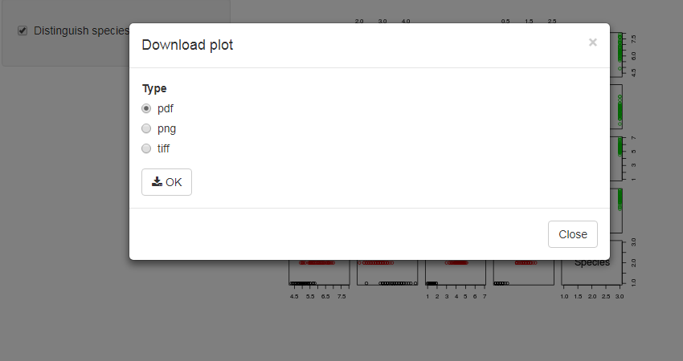

**UI:**

```r
library(shinyBS)

ui <- fluidPage(

  sidebarLayout(

    sidebarPanel(
      checkboxInput("groups",
                    "Distinguish species")
    ),

    mainPanel(
      plotOutput("plot"),

      bsModal("modal",
              "Download plot",
              "plot",
        radioButtons("type", "Type",
                     c("pdf", "png", "tiff")),
        downloadButton("down", "OK")
      )

    )
  )
)
```

**Exercise:** Create a pop-up when placing the mouse over the plot saying “save it”.

**Server:**

```r
server <- function(input, output) {

   output$plot <- renderPlot({
     if (input$groups)
       pairs(iris, col = iris[,5])
     else
       pairs(iris)
   }, width = 500)

   output$down <- downloadHandler(
     filename = function(){
       paste("figure", input$type, sep = ".")
     },
     content = function(ff){
      if (input$type == "pdf") pdf(ff)
      if (input$type == "png") png(ff)
      if (input$type == "tiff") tiff(ff)
      if (input$groups)
        pairs(iris, col = iris[,5])
      else
        pairs(iris)
      dev.off()
     }
   )
}
```

Collapse panels

### Collapse panels

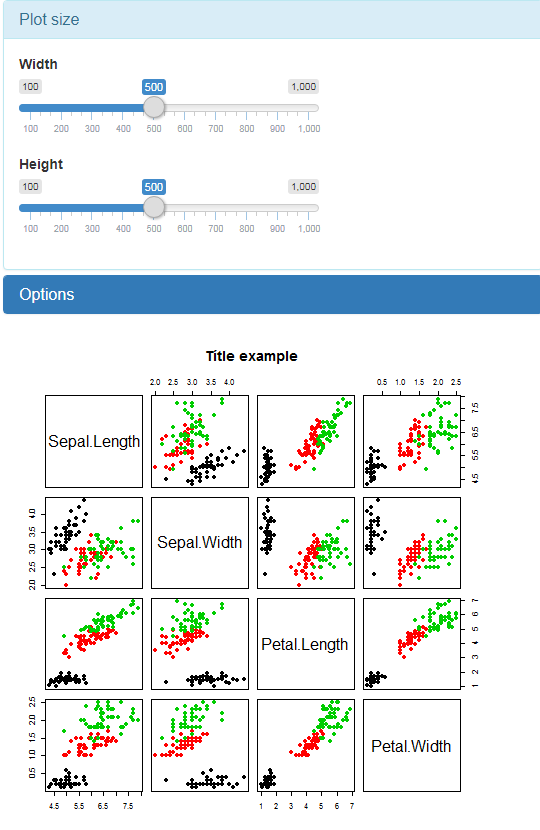

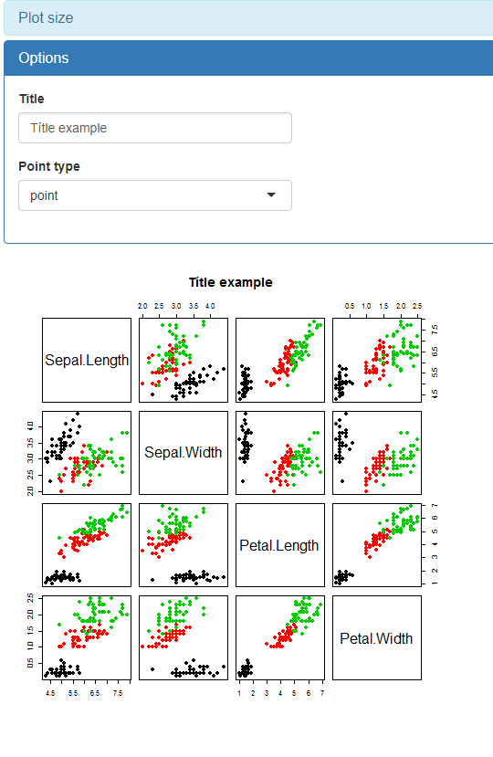

```r
library(shinyBS)
ui <- fluidPage(

  bsCollapse(id = "collapseExample", open = "Plot size",
    bsCollapsePanel("Plot size",
      sliderInput("width", "Width", 100, 1000, 500, 50),
      sliderInput("height", "Height", 100, 1000, 500, 50)
    , style = "info"),
    bsCollapsePanel("Options",
      textInput("main", "Title", "title"),
      selectInput("pch", "Point type",
                  c("point"=19, "squared"=22, "diamond"=23))
    , style = "primary")
  ),

  uiOutput("result")
)

server <- function(input, output) {
  output$plot <- renderPlot({
    pairs(iris[,-5], col=iris[,5],
          main = input$main,
          pch = as.double(input$pch))
  })
  output$result <- renderUI({
    plotOutput("plot", width=input$width, height=input$height)
  })
}

runApp(list(ui=ui,server=server))
```

**Exercise**: change the `multiple` argument from `bsCollapse` function to `TRUE`.

Carrouselles

### Carrouselles

- The **`bsplus`** packages allows to create carrouselles, among other features.
- This package is available on CRAN repository:

```r
install.packages(bsplus)
```

- Or install the last vresion from Github repository

```r
install.packages("devtools")
devtools::install_github("ijlyttle/bsplus")
```

- Visit **`bsplus`** webpage [here](http://ijlyttle.github.io/bsplus/)

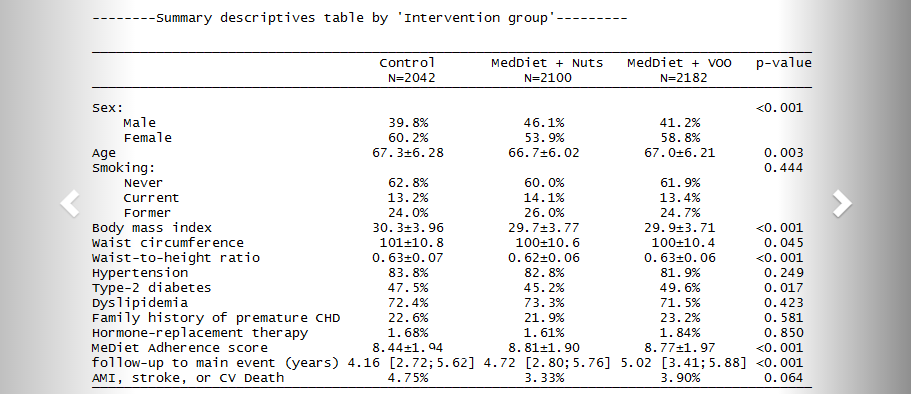

```r
library(bsplus); library(magrittr)

ui <- fluidPage(
  titlePanel("Carrouselles example"),
  HTML("<style type='text/css'> #carousel{height:700px;} </style>"),
  bs_carousel(id="carousel", use_indicators=TRUE, use_controls=TRUE)%>%
  bs_append(content=bs_carousel_image(src="example1.png", width="50%"))%>%
  bs_append(content=bs_carousel_image(src="example2.png", width="40%"))%>%
  bs_append(content=bs_carousel_image(src="example3.png", width="40%"))%>%
  bs_append(content=bs_carousel_image(src="example4.png", width="40%"))
)

server <- function(input, output) {}

shinyApp(ui = ui, server = server)
```

**Exercise:** Reprodue this example with four images files stored inside www folder

### Themes

**UI**

```r
library(shinythemes)

ui <- fluidPage(

  # specify the CSS theme or CSS file
  theme = shinytheme("united"),

  titlePanel("Example Shiny web"),
  sidebarLayout(
    sidebarPanel(
      selectInput("dataset", "Choose a dataset:",
                  c("rock", "pressure", "cars")),
      numericInput("obs",
              "Number of observations to view:", 10),
      helpText("Note: while the data view will
               show only the specified",
               "number of observations,
               the summary will still be based",
               "on the full dataset."),
      submitButton("Update View")
    ),
    mainPanel(
      tabsetPanel(type="pills",
        tabPanel("Summary",
          verbatimTextOutput("summary")
        ),
        tabPanel("Observations",
          tableOutput("view")
        )
      )
    )
  )
)
```

**Server**

```r
server <- function(input, output) {
  datasetInput <- reactive({
    switch(input$dataset,
           "rock"=rock,
           "pressure"=pressure,
           "cars"=cars)
  })
  output$summary <- renderPrint({
    dataset <- datasetInput()
    summary(dataset)
  })
  output$view <- renderTable({
    head(datasetInput(), n = input$obs)
  })
}
```

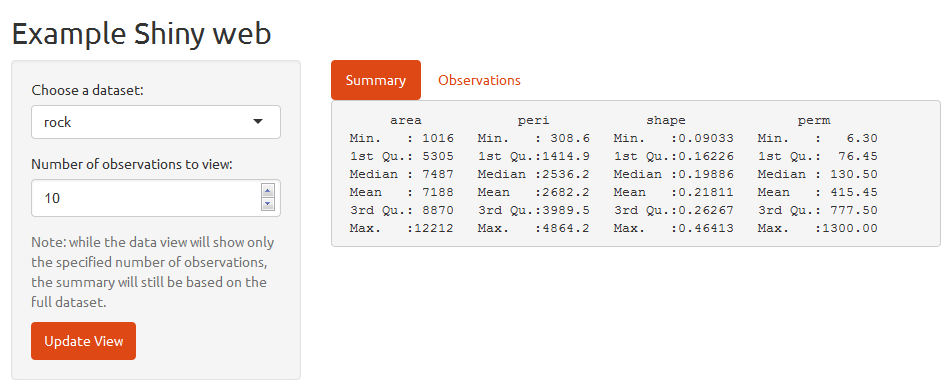

**Exercises:**

Change the argument `theme` to other theme.

Specify a CSS file from http://bootswatch.com/

### Sizeable

```r
library(shinyjqui)

ui <- fluidPage(

  jqui_resizabled(
    plotOutput('plot', '200px', '200px')
  )

)

server <- function(input, output) {
  output$plot <- renderPlot({
    plot(Sepal.Length ~ Sepal.Width, iris)
  })
}

shinyApp(ui, server)
```

Using the **`jqui_resizabled`** function from the **`shinyjqui`** package, you can resize interactively any widget (like a plot, input element or panel).

This package is available on CRAN and it also contains functions to drag or sort widgets.

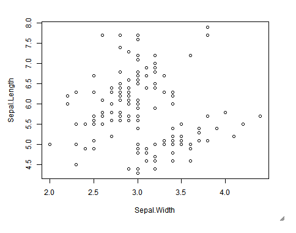

**Exercise:** Place a download button to save the plot.

### Input alerts

```r
require(shinyFeedback)

ui <- fluidPage(
  useShinyFeedback(),
  passwordInput("pass","Enter password"),
  actionButton("check","Check")
)

server <- function(input, output) {
 observeEvent(input$check, {
   feedback("pass",
            condition=input$pass!="123",
            text="Wrong passord",
            color="red")
  })
}

shinyApp(ui, server)
```

Using the **`feedback`** from the **`shinyFeedback`** package you can create alerts (with a message and colour) beside an input widget.

Its arguments are the contition, text and color.

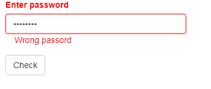

**Exercise:** Repeat this example for a `numericInput` like age, with 0-100 as range, and introducing the proper alert texts. Note that you can place more than one `feedback` (one for each condition).

Exercise

### Exercise

From the app created in part II:

- Add pop-ups.
- Modify some input element or panel appearance.
- Create collapse panels.
- Change the app appearance using `shinythemes`.
- Make the outputs (plot, summaries) resizable.
- Create an alert for parameters numericInputs.

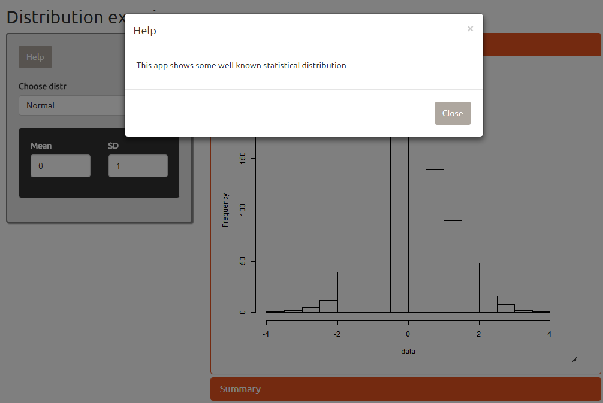